# Сравнение линейных моделей

Линейные модели…

Валентина Домашкина, Вадим Хайтов, Анастасия Лянгузова, Наталья Арбузова, Юта Тамберг, Марина Варфоломеева

Кафедра Зоологии беспозвоночных, СПбГУ

## Сравнение линейных моделей

## Мы рассмотрим

- Вложенные модели
- Тестирование значимости отдельных предикторов при помощи частного F-критерия
- Принципы отбора моделей
- Упрощение моделей

## Вы сможете

- Определять, какие модели являются вложенными
- Сравнивать вложенные модели при помощи частного F-критерия
- Объяснить связь между качеством описания существующих данных и краткостью модели
- Объяснить, что такое «переобучение» модели
- Упростить линейную модель при помощи частного F-критерия, следуя обратному пошаговому алгоритму

# Модель множественной линейной регрессии с прошлой лекции

## Пример: птицы в лесах Австралии

От каких характеристик лесного участка зависит обилие птиц в лесах юго-западной Виктории, Австралия (Loyn, 1987)

Переменных много, мы хотим из них выбрать **оптимальный небольшой** набор.

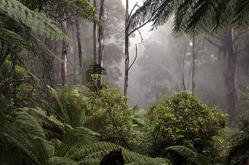

Mystic Forest - Warburton, Victoria by ¡kuba! on flickr

56 лесных участков:

- ABUND — обилие птиц
- AREA — площадь участка
- YRISOL — год изоляции участка
- DIST — расстояние до ближайшего леса
- LDIST — расстояние до ближайшего большого леса
- GRAZE — пастбищная нагрузка (1-5)
- ALT — высота над уровнем моря

Пример из кн. Quinn, Keugh, 2002, данные из Loyn, 1987)

## Модель из прошлой лекции

```r
bird <- read.csv("data/loyn.csv")
bird$logAREA <- log(bird$AREA)
bird$logDIST <- log(bird$DIST)
bird$logLDIST <- log(bird$LDIST)
mod2 <- lm(ABUND ~ logAREA + YRISOL + logDIST + logLDIST + ALT, data = bird)
```

$$\begin{aligned}\widehat{ABUND}_i = &-226.00 + 3.69 \cdot logAREA_i + 0.12 \cdot YRISOL_i \\
&- 0.10 \cdot logDIST_i - 0.33 \cdot logLDIST_i + 0.03 \cdot ALT_i\\
\end{aligned}$$

- Проверим ещё одним способом, влияют ли предикторы.
- Разберёмся, можно ли оптимизировать модель.

# Вложенные модели

## Вложенные модели (nested models)

Две модели являются **вложенными**, если одну из них можно получить из другой путём удаления некоторых предикторов.

Удаление предиктора — коэффициент при данном предикторе равен нулю.

### Полная модель (full model)

М1: $y_i = b_0 + b_1 x_{1i} + b_2 x_{2i} + e_i$

### Неполные модели (reduced models)

М2: $y_i = b_0 + b_1 x_{1i} + e_i$

М3: $y_i = b_0 + b_2 x_{2i} + e_i$

- М2 вложена в М1
- М3 вложена в М1
- М2 и М3 **не** вложены друг в друга

### Нулевая модель (null model)

$y_i = b_0 + e_i$ — вложена в полную (М1) и в неполные (М2, М3)

## Задание

Для тренировки запишем вложенные модели для данной полной модели:

1. $y_i = b_0 + b_1 x_{1i} + b_2 x_{2i} + b_3 x_{3i} + e_i$

## Решение

Для тренировки запишем вложенные модели для данной полной модели:

1. $y_i = b_0 + b_1 x_{1i} + b_2 x_{2i} + b_3 x_{3i} + e_i$

**Модели:**

- 2. $y_i = b_0 + b_1 x_{1i} + b_2 x_{2i} + e_i$
- 3. $y_i = b_0 + b_1 x_{1i} + b_3 x_{3i} + e_i$
- 4. $y_i = b_0 + b_2 x_{2i} + b_3 x_{3i} + e_i$
- 5. $y_i = b_0 + b_1 x_{1i} + e_i$
- 6. $y_i = b_0 + b_2 x_{2i} + e_i$
- 7. $y_i = b_0 + b_3 x_{3i} + e_i$
- 8. $y_i = b_0 + e_i$

**Вложенность:**

- (2)–(4) → в (1)
- 5. → в (1), (2), (3)
- 6. → в (1), (2), (4)
- 7. → в (1), (3), (4)
- 8. → во все

# Частный F-критерий

## Сравнение вложенных линейных моделей при помощи F-критерия

### Полная модель (со всеми предикторами)

$y_i = b_0 + b_1 x_{1i} + \ldots + b_k x_{ki} + b_l x_{li} + e_i$

$SS_{r, full}$, $df_{r, full} = p - 1$

$SS_{e, full}$, $df_{e, full} = n - p$

### Уменьшенная модель с $(p - 1)$ параметрами (например, без предиктора $b_l x_{li}$)

$y_i = b_0 + b_1 x_{1i} + \ldots + b_k x_{ki} + e_i$

$SS_{r, reduced}$, $df_{r, reduced} = (p - 1) - 1$

$SS_{e, reduced}$, $df_{e, reduced} = n - (p - 1)$

## Полная модель всегда будет лучше

$SS_{r, full} > SS_{r, reduced}$

или то же самое:

$SS_{e, full} < SS_{e, reduced}$

Можно оценить, насколько именно полная модель лучше уменьшенной (или насколько уменьшенная модель хуже полной).

## Частный F-критерий оценивает разницу объяснённой дисперсии между моделями

$$F = \frac{(SS_{e, reduced} - SS_{e, full})/(df_{e, reduced} - df_{e, full})}{SS_{e, full} / df_{e, full}}$$

**Если модель значимо ухудшается от удаления предиктора, то влияние этого предиктора значимо.**

## Краткое обозначение частного F-критерия

Чтобы проверить значимость предиктора `ALT`, нам нужно сравнить две модели:

`ABUND ~ logAREA + YRISOL + logDIST + logLDIST + ALT`  
`ABUND ~ logAREA + YRISOL + logDIST + logLDIST`

Это можно обозначить:

$F_{(\text{ALT | logAREA, YRISOL, logDIST, logLDIST})}$

А разницу остаточных сумм квадратов $SS_{e, reduced} - SS_{e, full}$, которую мы тестируем, можно обозначить:

$SS_{(\text{ALT | logAREA, YRISOL, logDIST, logLDIST})}$

## Частный F-критерий в R: `anova(модель_1, модель_2)`

Если высота над уровнем моря входит в модель после учёта влияния остальных предикторов, то её влияние не значимо ($F = 1.84$, $p = 0.18$).

$F_{(\text{ALT | logAREA, YRISOL, logDIST, logLDIST})}$

```r
mod2_reduced <- update(mod2, . ~ . - ALT)
anova(mod2_reduced, mod2)
```

```
Analysis of Variance Table

Model 1: ABUND ~ logAREA + YRISOL + logDIST + logLDIST
Model 2: ABUND ~ logAREA + YRISOL + logDIST + logLDIST + ALT
  Res.Df  RSS Df Sum of Sq    F Pr(>F)
1     51 2206
2     50 2128  1      78.2 1.84   0.18
```

## Характер влияния предиктора зависит от состава модели

Если высота над уровнем моря — единственный предиктор в модели, то его влияние статистически значимо ($F = 9.45$, $p < 0.05$).

$F_{(\text{ALT})}$

```r
mod_ALT1 <- lm(ABUND ~ ALT, data = bird)
mod_null <- lm(ABUND ~ 1, data = bird)
anova(mod_null, mod_ALT1)
```

```
Analysis of Variance Table

Model 1: ABUND ~ 1
Model 2: ABUND ~ ALT
  Res.Df  RSS Df Sum of Sq    F Pr(>F)
1     55 6338
2     54 5394  1       944 9.45 0.0033 **
---
Signif. codes:  0 '***' 0.001 '**' 0.01 '*' 0.05 '.' 0.1 ' ' 1
```

# I и II типы сумм квадратов

## Порядок проведения сравнений при F-тестах (типы сумм квадратов)

`Y ~ A + B + C`

### I тип сумм квадратов (SS type I)

Последовательно вычисляем вклады предикторов при условии, что все предыдущие включены в модель:

- $SS_{A}$
- $SS_{B|A}$
- $SS_{C|A, B}$

### II тип сумм квадратов (SS type II)

Поочерёдно вычисляем вклад каждого предиктора при условии, что все остальные включены в модель:

- $SS_{A|B, C}$
- $SS_{B|A, C}$
- $SS_{C|A, B}$

## Последовательное тестирование `anova(модель)`

```r
anova(mod2)
```

```
Analysis of Variance Table

Response: ABUND
          Df Sum Sq Mean Sq F value  Pr(>F)
logAREA    1   3471    3471   81.56 4.4e-12 ***
YRISOL     1    607     607   14.27 0.00042 ***
logDIST    1     28      28    0.67 0.41737
logLDIST   1     25      25    0.59 0.44687
ALT        1     78      78    1.84 0.18137
Residuals 50   2128      43
---
Signif. codes:  0 '***' 0.001 '**' 0.01 '*' 0.05 '.' 0.1 ' ' 1
```

## Осторожно: при последовательном тестировании результат зависит от порядка предикторов

Если мы поставим `ALT` первым, то изменится SS для других предикторов, а влияние самого `ALT` станет значимым (т.к. оно оценено без учёта других предикторов).

```r
mod2_reordered <- lm(ABUND ~ ALT + logAREA + YRISOL + logDIST + logLDIST,
                     data = bird)
anova(mod2_reordered)
```

```
Analysis of Variance Table

Response: ABUND
          Df Sum Sq Mean Sq F value        Pr(>F)
ALT        1    944     944   22.17 0.00002017033 ***
logAREA    1   2755    2755   64.74 0.00000000014 ***
YRISOL     1    502     502   11.81        0.0012 **
logDIST    1      4       4    0.09        0.7698
logLDIST   1      5       5    0.12        0.7290
Residuals 50   2128      43
---
Signif. codes:  0 '***' 0.001 '**' 0.01 '*' 0.05 '.' 0.1 ' ' 1
```

## Поочерёдное тестирование `Anova(модель)`

```r
library(car)
Anova(mod2)
```

```
Anova Table (Type II tests)

Response: ABUND
          Sum Sq Df F value     Pr(>F)
logAREA     1614  1   37.92 0.00000012 ***
YRISOL       437  1   10.26     0.0024 **
logDIST        0  1    0.01     0.9303
logLDIST       5  1    0.12     0.7290
ALT           78  1    1.84     0.1814
Residuals   2128 50
---
Signif. codes:  0 '***' 0.001 '**' 0.01 '*' 0.05 '.' 0.1 ' ' 1
```

## При поочерёдном тестировании результат НЕ зависит от порядка предикторов

```r
Anova(mod2_reordered)
```

```
Anova Table (Type II tests)

Response: ABUND
          Sum Sq Df F value     Pr(>F)
ALT           78  1    1.84     0.1814
logAREA     1614  1   37.92 0.00000012 ***
YRISOL       437  1   10.26     0.0024 **
logDIST        0  1    0.01     0.9303
logLDIST       5  1    0.12     0.7290
Residuals   2128 50
---
Signif. codes:  0 '***' 0.001 '**' 0.01 '*' 0.05 '.' 0.1 ' ' 1
```

## F-тест позволяет упростить модель

```r
Anova(mod2)
```

```
Anova Table (Type II tests)

Response: ABUND
          Sum Sq Df F value     Pr(>F)
logAREA     1614  1   37.92 0.00000012 ***
YRISOL       437  1   10.26     0.0024 **
logDIST        0  1    0.01     0.9303
logLDIST       5  1    0.12     0.7290
ALT           78  1    1.84     0.1814
Residuals   2128 50
---
Signif. codes:  0 '***' 0.001 '**' 0.01 '*' 0.05 '.' 0.1 ' ' 1
```

Если не все предикторы влияют, то, может, можно удалить лишние — то есть упростить модель?

# Отбор моделей

## Упрощение линейных моделей при помощи частного F-критерия

Постепенно удаляем предикторы. Модели обязательно должны быть вложенными!*

### Обратный пошаговый алгоритм (backward selection)

1. Подбираем полную модель.
2. Удаляем один предиктор (строим уменьшенную модель).
3. Тестируем отличие уменьшенной модели от полной.

Повторяем 2–3 для каждого из предикторов:

4. Выбираем предиктор для окончательного удаления: это предиктор, удаление которого минимально ухудшает модель. Модель без него будет «полной» для следующего раунда выбора оптимальной модели.

Повторяем 1–4 до тех пор, пока что-то можно удалить.

* — **Важно!** Начинать упрощать модель нужно со взаимодействий между предикторами. Если взаимодействие из модели удалить нельзя, то нельзя удалять и отдельно стоящие предикторы, из которых оно состоит. Но мы поговорим о взаимодействиях позже.

## Влияют ли предикторы?

Можем попробовать оптимизировать модель.

```r
summary(mod2)
```

```
Call:
lm(formula = ABUND ~ logAREA + YRISOL + logDIST + logLDIST +
    ALT, data = bird)

Residuals:
    Min      1Q  Median      3Q     Max
-15.439  -3.669   0.332   2.765  15.759

Coefficients:
             Estimate Std. Error t value   Pr(>|t|)
(Intercept) -226.0006    74.2526   -3.04     0.0037 **
logAREA        3.6882     0.5989    6.16 0.00000012 ***
YRISOL         0.1207     0.0377    3.20     0.0024 **
logDIST       -0.1033     1.1759   -0.09     0.9303
logLDIST      -0.3281     0.9417   -0.35     0.7290
ALT            0.0318     0.0235    1.36     0.1814
---
Signif. codes:  0 '***' 0.001 '**' 0.01 '*' 0.05 '.' 0.1 ' ' 1

Residual standard error: 6.52 on 50 degrees of freedom
Multiple R-squared:  0.664, Adjusted R-squared:  0.631
F-statistic: 19.8 on 5 and 50 DF,  p-value: 7.97e-11
```

## Что происходит на каждом шаге обратного пошагового алгоритма?

`anova(модель_1, модель_2)`

Подбираем полную модель, удаляем предикторы по одному, тестируем, ухудшилась ли модель. Для окончательного удаления на этом шаге выбираем предиктор, удаление которого меньше всего её ухудшает.

> Но мы пойдём другим путём. Все эти действия может выполнить одна функция `drop1()`.

## Частный F-критерий при помощи `drop1()` (шаг 1)

Тестируем значимость всех предикторов за один раз. Затем выбираем предиктор, удаление которого меньше всего ухудшает модель.

```r
drop1(mod2, test = "F")
```

```
Single term deletions

Model:
ABUND ~ logAREA + YRISOL + logDIST + logLDIST + ALT
         Df Sum of Sq  RSS AIC F value     Pr(>F)
<none>                2128 216
logAREA   1      1614 3742 245   37.92 0.00000012 ***
YRISOL    1       437 2565 224   10.26     0.0024 **
logDIST   1         0 2128 214    0.01     0.9303
logLDIST  1         5 2133 214    0.12     0.7290
ALT       1        78 2206 216    1.84     0.1814
---
Signif. codes:  0 '***' 0.001 '**' 0.01 '*' 0.05 '.' 0.1 ' ' 1
```

```r
# Нужно убрать logDIST
```

## Тестируем предикторы (шаг 2)

Удаляем выбранный предиктор и повторяем тесты снова. И т.д.

```r
# Убрали logDIST
mod3 <- update(mod2, . ~ . - logDIST)
drop1(mod3, test = "F")
```

```
Single term deletions

Model:
ABUND ~ logAREA + YRISOL + logLDIST + ALT
         Df Sum of Sq  RSS AIC F value      Pr(>F)
<none>                2128 214
logAREA   1      1628 3757 244   39.02 0.000000084 ***
YRISOL    1       437 2565 222   10.48      0.0021 **
logLDIST  1         9 2137 212    0.20      0.6532
ALT       1        81 2209 214    1.94      0.1701
---
Signif. codes:  0 '***' 0.001 '**' 0.01 '*' 0.05 '.' 0.1 ' ' 1
```

```r
# Нужно убрать logLDIST
```

## Тестируем предикторы (шаг 3)

```r
# Убрали logLDIST
mod4 <- update(mod3, . ~ . - logLDIST)
drop1(mod4, test = "F")
```

```
Single term deletions

Model:
ABUND ~ logAREA + YRISOL + ALT
        Df Sum of Sq  RSS AIC F value       Pr(>F)
<none>               2137 212
logAREA  1      2112 4248 248   51.39 0.0000000027 ***
YRISOL   1       502 2639 222   12.23      0.00097 ***
ALT      1       123 2260 213    2.99      0.08978 .
---
Signif. codes:  0 '***' 0.001 '**' 0.01 '*' 0.05 '.' 0.1 ' ' 1
```

```r
# Нужно убрать ALT
```

## Тестируем предикторы (шаг 4)

```r
# Убрали ALT
mod5 <- update(mod4, . ~ . - ALT)
drop1(mod5, test = "F")
```

```
Single term deletions

Model:
ABUND ~ logAREA + YRISOL
        Df Sum of Sq  RSS AIC F value        Pr(>F)
<none>               2260 213
logAREA  1      2473 4732 252    58.0 0.00000000046 ***
YRISOL   1       607 2867 224    14.2       0.00041 ***
---
Signif. codes:  0 '***' 0.001 '**' 0.01 '*' 0.05 '.' 0.1 ' ' 1
```

```r
# Больше ничего не убрать
```

## Итоговая модель

```r
summary(mod5)
```

```
Call:
lm(formula = ABUND ~ logAREA + YRISOL, data = bird)

Residuals:
   Min     1Q Median     3Q    Max
-14.96  -3.80  -0.01   4.04  16.72

Coefficients:
             Estimate Std. Error t value      Pr(>|t|)
(Intercept) -252.1952    69.5868   -3.62       0.00065 ***
logAREA        3.7318     0.4900    7.62 0.00000000046 ***
YRISOL         0.1352     0.0358    3.77       0.00041 ***
---
Signif. codes:  0 '***' 0.001 '**' 0.01 '*' 0.05 '.' 0.1 ' ' 1

Residual standard error: 6.53 on 53 degrees of freedom
Multiple R-squared:  0.643, Adjusted R-squared:  0.63
F-statistic: 47.8 on 2 and 53 DF,  p-value: 1.35e-12
```

## Задание

Проверьте финальную модель на выполнение условий применимости. Дополните код.

## Решение: 1) График расстояния Кука

- Выбросов нет

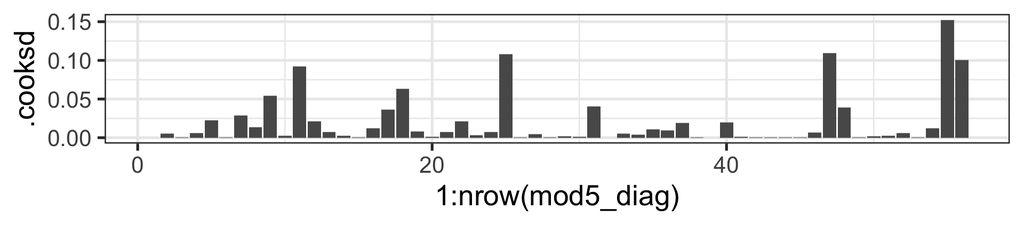

## Решение: 2) График остатков от предсказанных значений

- Выбросов нет
- Гетерогенность дисперсии?
- Два наблюдения с очень большими предсказанными значениями и большими остатками. Хорошо бы проверить их.

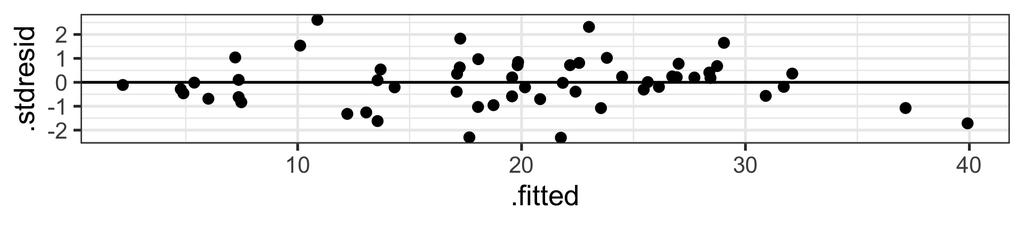

## Решение: 3) Графики остатков от предикторов

- Величина остатков зависит от уровня выпаса скота. Возможно, не стоило удалять эту переменную
- Есть наблюдения с экстремальными значениями предикторов (два больших леса, один далёкий, один высокогорный). Хорошо бы проверить их.

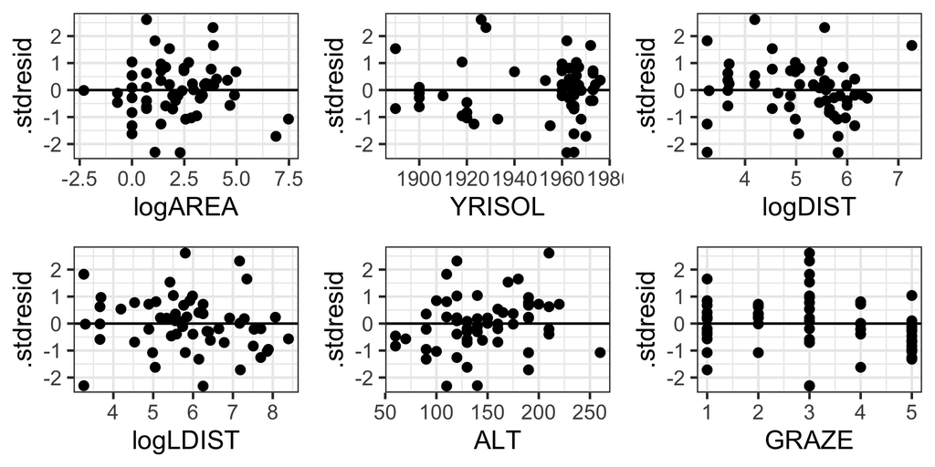

## Решение: 3) Код для графиков остатков от предикторов

```r
res_1 <- gg_resid + aes(x = logAREA)
res_2 <- gg_resid + aes(x = YRISOL)
res_3 <- gg_resid + aes(x = logDIST)
res_4 <- gg_resid + aes(x = logLDIST)
res_5 <- gg_resid + aes(x = ALT)
res_6 <- gg_resid + aes(x = GRAZE)

library(gridExtra)
grid.arrange(res_1, res_2, res_3, res_4,
             res_5, res_6, nrow = 2)
```

## Решение: 4) Квантильный график остатков

- Отклонения от нормального распределения остатков незначительны

```
[1] 11 47
```

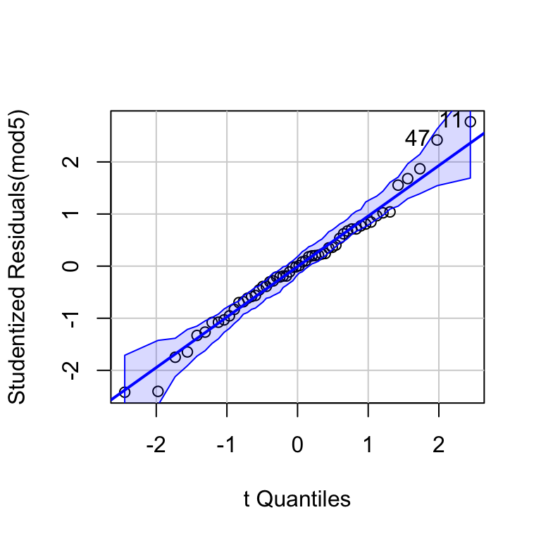

## Описываем финальную модель

```r
summary(mod5)
```

```
Call:
lm(formula = ABUND ~ logAREA + YRISOL, data = bird)

Residuals:
   Min     1Q Median     3Q    Max
-14.96  -3.80  -0.01   4.04  16.72

Coefficients:
             Estimate Std. Error t value      Pr(>|t|)
(Intercept) -252.1952    69.5868   -3.62       0.00065 ***
logAREA        3.7318     0.4900    7.62 0.00000000046 ***
YRISOL         0.1352     0.0358    3.77       0.00041 ***
---
Signif. codes:  0 '***' 0.001 '**' 0.01 '*' 0.05 '.' 0.1 ' ' 1

Residual standard error: 6.53 on 53 degrees of freedom
Multiple R-squared:  0.643, Adjusted R-squared:  0.63
F-statistic: 47.8 on 2 and 53 DF,  p-value: 1.35e-12
```

## График предсказаний модели: один предиктор

$$\widehat{ABUND}_i = -252.20 + 3.73 \cdot logAREA_i + 0.14 \cdot YRISOL_i$$

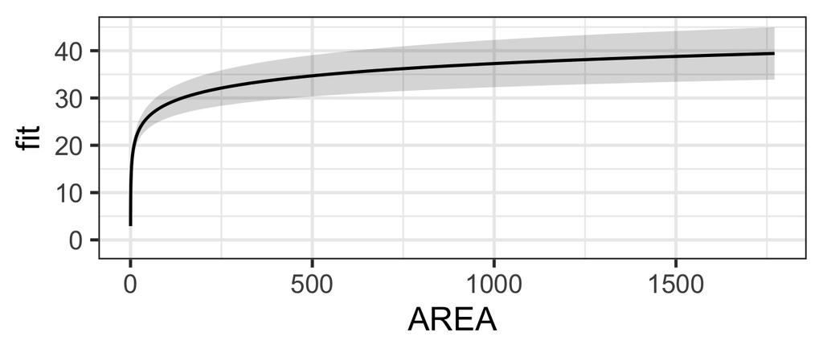

## Задание: постройте график предсказаний модели

Отобразите, как меняются значения зависимой переменной в зависимости от значений одного из предикторов, при условии, что другие предикторы принимают свои средние значения. Дополните этот код:

## Код для графика предсказаний модели: один предиктор

$$\widehat{ABUND}_i = -252.20 + 3.73 \cdot logAREA_i + 0.14 \cdot YRISOL_i$$

```r
# Искусственный датафрейм для предсказаний
MyData1 <- data.frame(
  logAREA = seq(min(bird$logAREA), max(bird$logAREA), length.out = 100),
  YRISOL = mean(bird$YRISOL))
# Предсказанные значения
Predictions1 <- predict(mod5, newdata = MyData1, interval = 'confidence')
MyData1 <- data.frame(MyData1, Predictions1)
# Обратная трансформация предиктора, который будем изображать
MyData1$AREA <- exp(MyData1$logAREA)
# График предсказаний модели
Pl_predict1 <- ggplot(MyData1, aes(x = AREA, y = fit)) +
  geom_ribbon(alpha = 0.2, aes(ymin = lwr, ymax = upr)) +
  geom_line()
Pl_predict1
```

## График предсказаний модели: два предиктора

$$\widehat{ABUND}_i = -252.20 + 3.73 \cdot logAREA_i + 0.14 \cdot YRISOL_i$$

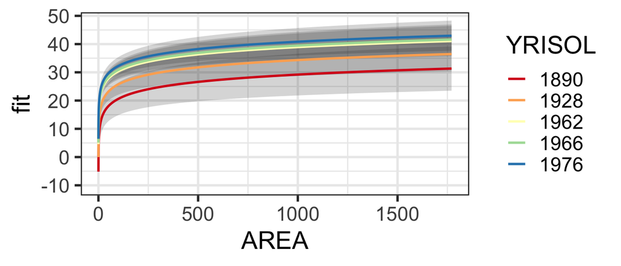

## Код для графика предсказаний модели: два предиктора

$$\widehat{ABUND}_i = -252.20 + 3.73 \cdot logAREA_i + 0.14 \cdot YRISOL_i$$

```r
# Искусственный датафрейм для предсказаний
MyData2 <- expand.grid(
  logAREA = seq(min(bird$logAREA), max(bird$logAREA), length.out = 100),
  YRISOL = round(quantile(bird$YRISOL)))
# Предсказанные значения
Predictions2 <- predict(mod5, newdata = MyData2, interval = 'confidence')
MyData2 <- data.frame(MyData2, Predictions2)
# Обратная трансформация предиктора, который будем изображать
MyData2$AREA <- exp(MyData2$logAREA)
# Делаем год фактором
MyData2$YRISOL <- factor(MyData2$YRISOL)
# График предсказаний модели
Pl_predict2 <- ggplot(MyData2, aes(x = AREA, y = fit, group = YRISOL)) +
  geom_ribbon(alpha = 0.2, aes(ymin = lwr, ymax = upr)) +
  geom_line(aes(colour = YRISOL)) +
  scale_colour_brewer(palette = 'Spectral')
Pl_predict2
```

## Недостатки этой модели

$$\widehat{ABUND}_i = -252.20 + 3.73 \cdot logAREA_i + 0.14 \cdot YRISOL_i$$

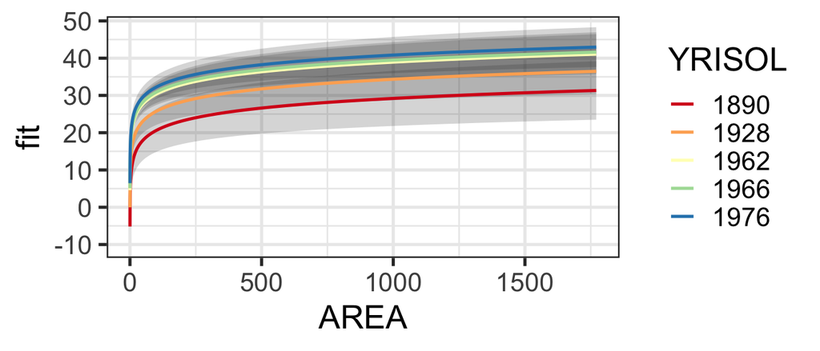

- Отрицательные предсказания для очень давно изолированных маленьких лесов (обилие птиц не может быть отрицательным).
- Не учтён уровень выпаса скота из-за коллинеарности с другими предикторами (но он особенно интересен исследователям, и остатки от него зависят).
- В выборке очень мало лесов большой площади — место, где кривая выходит на плато, плохо поддержано данными.

## Недостатки и ограничения методологии отбора моделей

- Разные способы отбора оптимальной модели могут приводить к разным результатам. Не важно, какой из способов выбрать, но важно сделать это заранее, **до анализа**, чтобы не поддаваться соблазну подгонять результаты.
- При отборе моделей приходится делать множество тестов, поэтому увеличивается риск ошибок I рода (подробнее на занятии про дисперсионный анализ). Чтобы хоть как-то себя обезопасить, лучше не включать в модель всё подряд — только самое необходимое.
- Оптимальную модель лучше применять для тестирования гипотез на независимых данных, иначе получаются заниженные стандартные ошибки и завышенные эффекты. Обычно эту проблему игнорируют, но если у вас есть возможность, лучше сделать хотя бы кросс-валидацию.
- Какой-то одной «лучшей» модели, как правило, не существует.

## Take-home messages

- Модели, которые качественно описывают существующие данные, включают много параметров, но предсказания с их помощью менее точны из-за переобучения.
- Для выбора оптимальной модели используются разные критерии в зависимости от задачи.
- Сравнивая модели, можно отбраковать переменные, включение которых в модель не улучшает её.
- **Метод сравнения моделей нужно выбрать заранее, ещё до анализа.**

## Что почитать

- Must read paper! Zuur, A.F. and Ieno, E.N., 2016. A protocol for conducting and presenting results of regression‐type analyses. Methods in Ecology and Evolution, 7(6), pp.636-645.
- Кабаков Р.И. R в действии. Анализ и визуализация данных на языке R. М.: ДМК Пресс, 2014
- Zuur, A., Ieno, E.N. and Smith, G.M., 2007. Analyzing ecological data. Springer Science & Business Media.
- Quinn G.P., Keough M.J. 2002. Experimental design and data analysis for biologists
- Logan M. 2010. Biostatistical Design and Analysis Using R. A Practical Guide